# Advanced Topic Instructions

Sandra Velazco

5/11/2020

## Research introduction

In the tropical Andes, bracken fern due to its vigor and rapid colonization inhibits the establishment of the native plants, delaying the recovery of the montane forest. My study investigate whether the distance and shape of Bracken fern-dominated patches from the forest affect natural regeneration in these patches in the north of Peru between 2014 and 2019. Satellite imagery of the Sentinel sensor from the last five years will be used to measure the vegetation index (NDVI) in each patch. Temporal changes in vegetation index within and between patches will be used as a measure of native vegetation recovery in the region.

## Introduction to problem

An expected result is that the configuration of Bracken fern patches will determine natural regeneration in these degraded areas. So, my first step to accomplish this goal will be to measure the distance between bracken fern and forest edge pixels, applying the nearest neighbor analysis. To accomplish this first step, I will use sample data to test the efficiency of different packages in analyzing the pairwise distances between fern and forest pixels.

A current challenge to conduct this analysis is to calculate the distance between pixels considering elevation. Given that, the selection of packages and functions that take into account topographic distances is essential to perform a correct spatial analysis. The development of this advanced topic has been useful to explore different tools for measuring geographical distances, considering the heterogeneity of a region.

## PSEUDOCODE

```r
## Load the libraries

library(googledrive)# I used this package to download files from googledrive into Rmarkdonw
options(
  gargle_oauth_cache = ".secrets",
  gargle_oauth_email = TRUE
)

library(here)# It was used to define file paths.
library(raster)# Used for raster file
library(rgdal)# This package allowed to project and transform spatial data.
library(sp)# Used for shapefiles
library(sf)# Used for dataframe
library(dplyr)# Used for organize dataframe
```

```r
library(gdistance)# This package is used to measure distance based on topographic information
library(Matrix)# This package allow getting distance matrix
library(igraph)# Used to measure distance based on vertices in the network
library(reshape2)# Used for dataframe
library(tibble)# To organize dataframe
#
```

```r
## Donwloading files from googledrive:
folder_url <- "https://drive.google.com/drive/folders/1r8XsNTTKWCiWHSxR_ldISpLHzZJbla3o"

folder <- drive_get(as_id(folder_url))
```

[output not shown]

```
## Auto-refreshing stale OAuth token.
```

```r
gdrive_files <- drive_ls(folder)
lapply(gdrive_files$id, function(x) drive_download(as_id(x),
                                                   path = paste0(here::here("datatemp/original/"), "/",gdrive_files[gdrive_files$id==x,]$name), overwrite = TRUE))
```

```
## File downloaded:
##   * data_sample.csv
## Saved locally as:
##   * C:/Users/Sandra/Desktop/R files/Stats/RMarkdownAssignment_Sandra/datatemp/original/data_sample.csv
```

```
## File downloaded:
##   * raster.tif
## Saved locally as:
##   * C:/Users/Sandra/Desktop/R files/Stats/RMarkdownAssignment_Sandra/datatemp/original/raster.tif
```

[output not shown]

```r
## Uploading files from directory
pixels <- read.csv(here::here("datatemp/original/data_sample.csv"), stringsAsFactors = FALSE)
elev=raster::raster(here::here("datatemp/original/raster.tif"))
## Check the data: pixels file
class(pixels)
```

```
## [1] "data.frame"
```

```r
dim(pixels)
```

```
## [1] 96  6
```

```r
colnames(pixels)
```

```
## [1] "Long"     "Lat"      "ID_pixel" "ID_veg"   "loc"      "ndvi"
```

```r
ncol(pixels)
```

```
## [1] 6
```

```r
nrow(pixels)
```

```
## [1] 96
```

```r
##############################################################
################  Processing files  ##########################
##############################################################

######## Step1: Extract elevation data from raster file

## Project pixels dataframe using elev raster projection
crs
```

[output not shown]

```r
elev@crs
```

```
## CRS arguments:
##  +proj=longlat +datum=WGS84 +no_defs +ellps=WGS84 +towgs84=0,0,0
```

```r
pixels_spdf <- SpatialPointsDataFrame(
              pixels[,1:2],proj4string=elev@crs, pixels)
class(pixels)
```

```
## [1] "data.frame"
```

```r
## I used extract funtion to get elevation data from the raster image.
pixel_elev <- raster::extract(elev, # raster layer
              pixels_spdf,   # SPDF with pixels
              df=TRUE)         # return a dataframe
## Then I grabbed the name of the ID_pixel from the pixels_spdf
pixel_elev$pix_id<- pixels_spdf$ID_pixel
## Fix the column names
names(pixel_elev) <- c('ID','elev','pix_id')
## The pixels and pixel_elev data were merged, using merge function from package base.
pixelelev <- merge(pixels, pixel_elev, by.x = 'ID_pixel', by.y = 'pix_id')

######## Step2: Assign the UTM projection to pixelelev and to raster file to measure distance using different package.

## Define the projection to reproject the pixele
CRS("+init=epsg:32717")
```

```
## CRS arguments:
##  +init=epsg:32717 +proj=utm +zone=17 +south +datum=WGS84 +units=m
## +no_defs +ellps=WGS84 +towgs84=0,0,0
```

```r
#crs = " +init=epsg:32717 +proj=utm +zone=17 +south +datum=WGS84 +units=m +no_defs +ellps=WGS84 +towgs84=0,0,0"
## Assign function for projecting pixelelev to UTM.
LongLatToUTM<-function(x,y,ID,zone){
          xy <- data.frame(ID = ID, x = x, y = y)
          coordinates(xy) <- c("x", "y")
          proj4string(xy) <- CRS("+proj=longlat +datum=WGS84")
          res <- spTransform(xy, CRS(paste("+proj=utm +south +zone=",zone," +ellps=WGS84 +units=m +no_defs +towgs84=0,0,0", sep='')))
          return(as.data.frame(res))
          }
## Assign the UTM zone and run the function
x=LongLatToUTM(pixelelev$Long,pixelelev$Lat,ID=pixelelev$ID_pixel,17)
## Merge the new UTM coordinates to the locations dataframe.
x$ID_pixel=x$ID
pixelelev= merge(pixelelev,x,by="ID_pixel")
## Change names of variables in the dataframe
names(pixelelev)
```

```
##  [1] "ID_pixel" "Long"     "Lat"      "ID_veg"   "loc"      "ndvi"
##  [7] "ID.x"     "elev"     "ID.y"     "x"        "y"
```

```r
df=pixelelev
names(df)=c("ID_pixel","Long","Lat","ID_veg","loc","ndvi","ID.x","z","ID.y","x","y")
## Arrange according ID_veg
df <- df[order(df$ID_veg),]
## Define the projection to reproject the raster file from lat long into UTM
CRS("+init=epsg:32717")
```

```
## CRS arguments:
##  +init=epsg:32717 +proj=utm +zone=17 +south +datum=WGS84 +units=m
## +no_defs +ellps=WGS84 +towgs84=0,0,0
```

```r
sr <- "+proj=utm +south +zone=17 +ellps=WGS84 +units=m +no_defs +towgs84=0,0,0"
## Reproject Raster
elev_utm <- projectRaster(elev, crs = sr)
## Transform df dataframe into sf object and assign geometry.
coordnt=st_as_sf(df, coords = c("x", "y"), crs = ("+init=epsg:32717"),stringsAsFactors = FALSE)
class(coordnt)
```

```
## [1] "sf"         "data.frame"
```

```r
######## Step3: Processing raster file
## Transforming raster utm file into shapefile
elev_shape = rasterToPolygons(elev_utm,na.rm=TRUE)
class(elev_shape)
```

```
## [1] "SpatialPolygonsDataFrame"
## attr(,"package")
## [1] "sp"
```

```r
## Saving shapefile elev_shape in folder
writeOGR(elev_shape,"elev_shape", dsn="C:/Users/Sandra/Desktop/R files/Stats/RMarkdownAssignment_Sandra/datatemp", driver="ESRI Shapefile",overwrite=TRUE)
## Call shapefile elev_utm_shape and transform into sf file
elev_shape <- st_read("C:/Users/Sandra/Desktop/R files/Stats/RMarkdownAssignment_Sandra/datatemp/elev_shape.shp")%>%
       st_transform(crs = 32717)
##############################################################
################  Gdistance package ##########################
##############################################################

######## Step1: Creation of a transition matrix from the elev_utm raster file

### The units of height and distance should be identical
### Set upt a function for elevation
altDiff <- function(x){x[2] - x[1]}
## Run the function to get a transition matrix
hd <- transition(elev_utm, altDiff, 8, symm=FALSE)
```

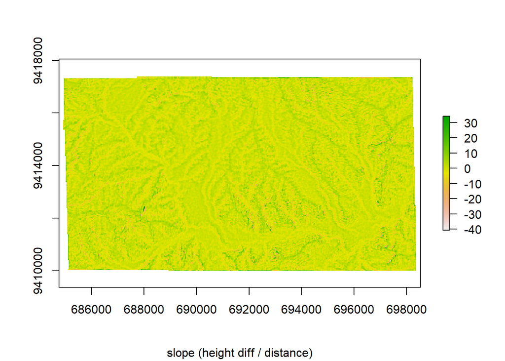

```r
plot(raster(hd), sub="slope (height diff / distance)", cex=0.8)
```

```r
## Then we use the function geoCorrection to divide by the distance between cells. Slope = differenceinheight/distancetravelled
slope <- geoCorrection(hd, scl=FALSE)
## Inspect a transition matrix for the slope
round(transitionMatrix(slope),3)
```

[output not shown]

[output cut: 3217 more lines]

```r
## Restrict the calculaton of speed to adjacent cells
adj <- adjacent(elev_utm, cells=1:ncell(elev_utm), pairs=TRUE, directions=8)
speed <- hd
## Adjust the distance using the slope(diagonal distance)
speed[adj] <- 6 * exp(-3.5 * abs(slope[adj] + 0.05))
## Geocorrect again for distance to create a time matrix.
conductance <- geoCorrection(speed)
## Calculate distance using the least cost distance
dist2 <- costDistance(conductance,
                      fromCoords = as(as_Spatial(coordnt[1:56,]), "SpatialPoints"),
                      toCoords = as(as_Spatial(coordnt[-(1:56),]), "SpatialPoints"))

######## Step2: The nearest distance selection between fern pixels and forest pixels

## Drop geometry
coord_df <- st_drop_geometry(coordnt)
### Subset columns from datafrane coordnt
ID_pixels<-coord_df[, 1]
### Assign ID names to row and columns of dist2 matrix
rownames(dist2) <- ID_pixels[1:56]
colnames(dist2) <- ID_pixels[57:96]
## Rename column names of dist2 matrix
dist2_id <- melt(as.matrix(dist2), varnames = c("fern", "forest"))
## Convert matrix into dataframe
dist2_id[dist2_id$fern > dist2_id$forest,]
```

[output not shown]

[output cut: 2186 more lines]

[output not shown]

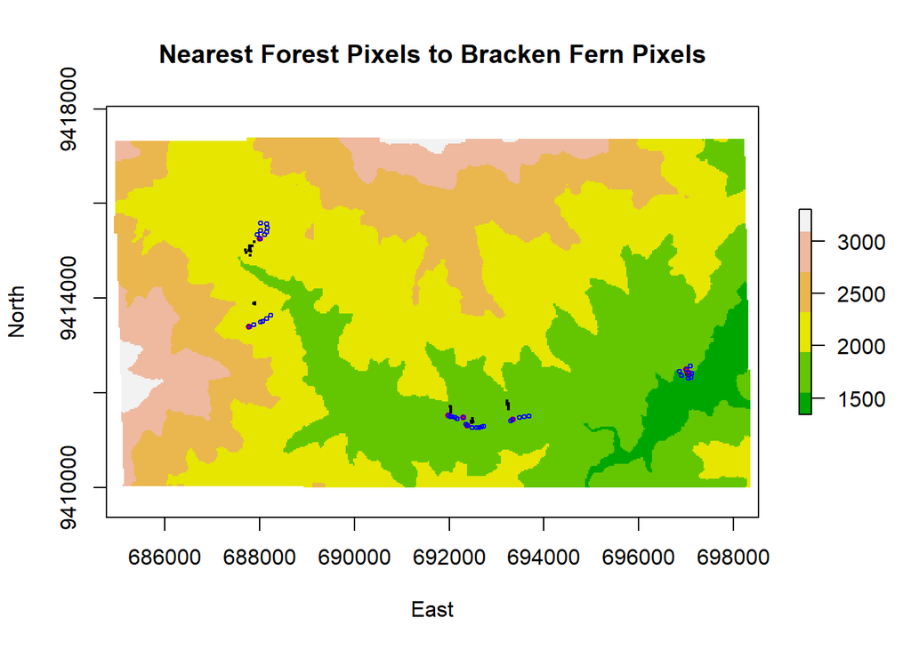

```r
## Find the minimun distance between bracken fern and forest pixels
summ_fern_value<- dist2_id %>%
  group_by(fern) %>%
  summarise(min = min(value, na.rm = TRUE))
## Rename column name of summ_fern_value dataframe
fernvalue<- summ_fern_value %>% rename(value = min)
## Select forest pixel that match fern pixels and values
neardistance <- right_join(dist2_id,fernvalue, by=c("value","fern"))
view(neardistance)

######## Step3: Plot the nearest bracken fern and forest pixels

## Extract fern and forest ID of neardistance dataframe
nearforest<-neardistance$forest
nearfern<-neardistance$fern
## Combine fern and forest factor into one column
fern_f<-combine(nearforest,nearfern)
## Convert factors into dataframe
fernf <-data.frame(fern_f)
## Change column name of dataframe
fernid<- fernf %>% rename(ID_pixel = fern_f)
## Matching using ID_pixel
near <- right_join(df,fernid, by=c("ID_pixel"))
## Convert dataframe to tibble dataframe
dfnear<- as_tibble(near)
## Removing duplicated rows
dfpixel <- distinct(dfnear, ID_pixel, .keep_all = TRUE)
## Extracting x,y coordinates from df dataframe
dfern<-df[1:56,10:11]
dforest<-df[57:96,10:11]
## Extracting x,y coordinates from dfpixel to plot the nearest forest pixels to bracken fern patches
dfforest<-dfpixel[1:8,10:11]
nearforest<-as.data.frame(dfforest)
view(nearforest)
## Plot nearest bracken fern and forest pixels
myCol <- terrain.colors(6)
plot(elev_utm, main= "Nearest Forest Pixels to Bracken Fern Pixels", xlab="East", ylab="North",col=myCol,cex=.5)
points(dfern$x,dfern$y,col="black",pch=19,cex=.3)
points((nearforest$x),
      (nearforest$y),col="red",pch=19,cex=.6)
points(dforest$x,dforest$y,col="blue",cex=.5)
```

```r
##############################################################
################  Igraph package #############################
##############################################################

######## Step1: Creation of a hexagonal grid

## Use elev_shape shapefile to create a hexagonal grid using. Cellsize=8 was chosen to match small grids with the distance between pixel points
hex_elev_shape <- st_make_grid(elev_shape, cellsize = 8, square = FALSE)

######## Step2: Creation of an igraph network and a distance matrix

## First create an edgelist (i.e. list to ‘from’ and ‘to’ cell id’s that represent neighbours)
edgelist <- as.matrix(as.data.frame(st_intersects(hex_elev_shape)))
## Then convert into a igraph network, it will represent neighbouring cells
gr <- graph_from_edgelist(edgelist, directed=TRUE)
## Assign distance value (8m) between each neighbouring cell, this value was defined when the grid was created
E(gr)$weight <- 8
## Load pixels locations in the hexagonal grid
hex_pixels <- as.numeric(st_intersects(coordnt, hex_elev_shape))
## Deletion of duplicated values in the grid
hex_pixels <- unique(as.numeric(st_intersects(coordnt, hex_elev_shape)))
## Calculating the distance between bracken fern and forest pixels
dist3 <- distances(gr, hex_pixels[(1:56)], hex_pixels[-(1:56)])
view(dist3)

######## Step3: The nearest distance selection between fern pixels and forest pixels

## Drop geometry of coordnt spatial dataframe
coord_df <- st_drop_geometry(coordnt)
## Subset ID_pixels from datafrane coordnt
ID_pixels<-coord_df[, 1]
## Assign ID names to row and columns of dist2 matrix
rownames(dist3) <- ID_pixels[1:56]
colnames(dist3) <- ID_pixels[57:96]
## Rename columns of dist2 matrix
dist3_id <- melt(as.matrix(dist3), varnames = c("fern", "forest"))
## Convert dist3_id into dataframe
dist3_id[dist3_id$fern > dist3_id$forest,]
```

[output not shown]

[output cut: 2186 more lines]

[output not shown]

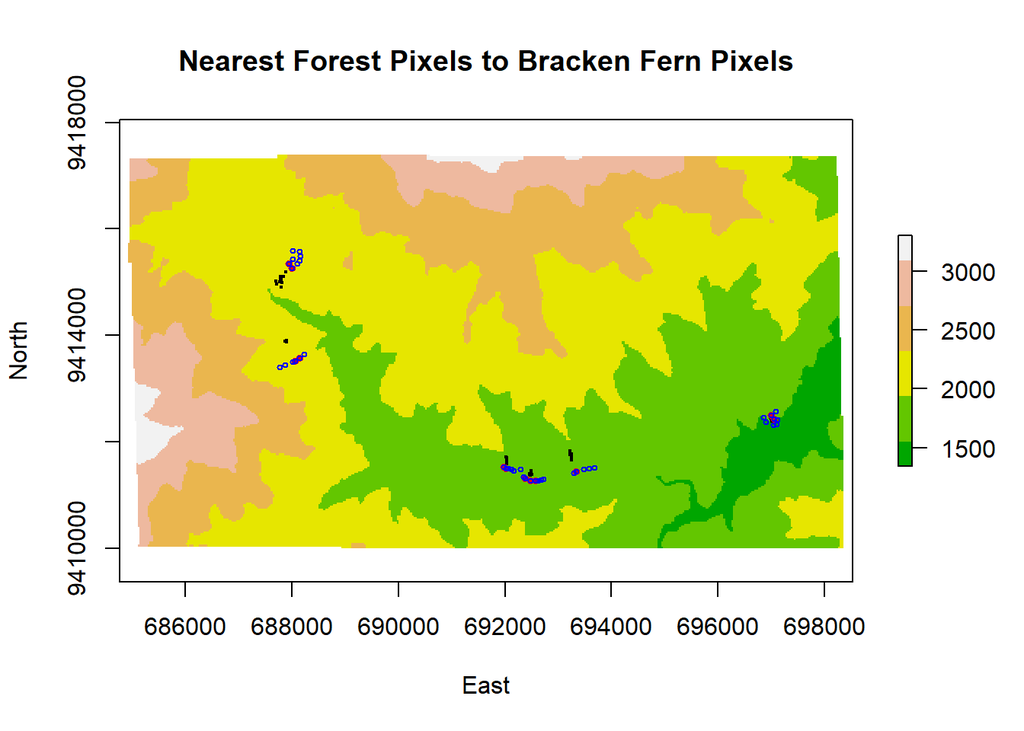

```r
## Find the minimun distance between bracken fern and forest pixels
fern_value<- dist3_id %>%
  group_by(fern) %>%
  summarise(min = min(value, na.rm = TRUE))
## Rename the column of dist3 matrix
fernvalue<- fern_value %>% rename(value = min)
## Select forest pixel that match fern pixels and values
neardist3 <-right_join(dist3_id,fernvalue, by=c("value","fern"))
view(neardist3)

######## Step4: Plot of the nearest bracken fern and forest pixels

## Extract fern and forest ID of the neardist3 dataframe
nfo_dist3<-neardist3$forest
nfe_dist3<-neardist3$fern
## Combine fern and forest factor into one column
fern_fdist3<-combine(nfo_dist3,nfe_dist3)
## Convert factors into a dataframe
fernfdist3 <-data.frame(fern_fdist3)
## Change column name of dataframe
fernidist3<- fernfdist3 %>% rename(ID_pixel = fern_fdist3)
## Matching using ID_pixel
near_dist3 <- right_join(df,fernidist3, by=c("ID_pixel"))
## Convert dataframe to tibble
dfnear_dist3<- as_tibble(near_dist3)
## Remove duplicated rows from dfnear_dist3 dataframe
dfpixel_dist3 <- distinct(dfnear_dist3, ID_pixel, .keep_all = TRUE)
## Extract x,y coordinates of bracken fern and forest from dfpixel_dist3
dfern_dist3<-df[1:56,10:11]
dforest_dist3<-df[57:96,10:11]
## Extracting x,y coordinates from dfpixel_dist3 to plot the nearest forest pixels to bracken fern patches
dffo_dist3<-dfpixel_dist3[1:12,10:11]
## Plot nearest bracken fern and forest pixels
myCol <- terrain.colors(6)
plot(elev_utm, main= "Nearest Forest Pixels to Bracken Fern Pixels", xlab="East", ylab="North", col=myCol,cex=.5)
points(dfern_dist3$x,dfern_dist3$y, col="black",pch=19,cex=.3)
points((dffo_dist3$x),
      (dffo_dist3$y),col="red",pch=19,cex=.6)
points(dforest_dist3$x,dforest_dist3$y,col="blue",cex=.5)
```

```r
#################################################################
################ Euclidean function #############################
#################################################################

######## Step1: Calculating distance matrix

## Set up a function for distance matrix
distxyz.fx=function(x1,x2,y1,y2,z1,z2){
  sqrt((x1-x2)^2+(y1-y2)^2+(z1-z2)^2)
}
dist.fx=function(x1,x2,y1,y2){
  sqrt((x1-x2)^2+(y1-y2)^2)
}
## Run the function and calculate distance matrix containing pairwise distances between fern patches and forest patches
df_forest=df[df$ID_veg=="forest",]
df_fern=df[df$ID_veg=="fern",]
distmat=matrix(NA,nrow=nrow(df_fern),ncol=nrow(df_forest))
for(i in 1:nrow(df_fern)){
  distmat[i,]=distxyz.fx(df_fern$x[i],df_forest$x,
                         df_fern$y[i],df_forest$y,
                         df_fern$z[i],df_forest$z)
  }
# Select the nearest forest patch for each fern patch
nearest_forest_id=rep(NA, nrow(df_fern))
nearest_forest_dist=rep(NA, nrow(df_fern))
for(i in 1:length(nearest_forest_id)){
  nearest_forest_id[i] = which(distmat[i,] == range(distmat[i,])[1])
  nearest_forest_dist[i] = distmat[i, which(distmat[i,] == range(distmat[i,])[1])]
}
df_fern$nearForestID=nearest_forest_id
df_fern$nearForestDist=nearest_forest_dist

######## Step2: Identifying the nearest forest pixels and bracken pixels

### Assign ID to row and columns of distmat matrix
df_ID_pixels <- df[,1]
df_ID_pixels
```

```
##  [1] "AG01_B1"  "AG01_B10" "AG01_B2"  "AG01_B3"  "AG01_B4"  "AG01_B5"
##  [7] "AG01_B6"  "AG01_B7"  "AG01_B8"  "AG01_B9"  "AG02_B1"  "AG02_B11"
## [13] "AG02_B12" "AG02_B14" "AG02_B15" "AG02_B3"  "AG02_B5"  "AG02_B7"
## [19] "AG02_B8"  "AG02_B9"  "PV_B1"    "PV_B10"   "PV_B2"    "PV_B3"
## [25] "PV_B4"    "PV_B5"    "PV_B6"    "PV_B7"    "PV_B8"    "PV_B9"
## [31] "SH_B1"    "SH_B12"   "SH_B2"    "SH_B20"   "SH_B24"   "SH_B25"
## [37] "SH_B28"   "SH_B34"   "SH_B4"    "SH_B41"   "SL_1"     "SL_2"
## [43] "SL_3"     "SL_4"     "SL_6"     "SL_7"     "YS_B10"   "YS_B15"
## [49] "YS_B2"    "YS_B22"   "YS_B25"   "YS_B28"   "YS_B34"   "YS_B38"
## [55] "YS_B4"    "YS_B5"    "AG01_F1"  "AG01_F2"  "AG01_F3"  "AG01_F4"
## [61] "AG01_F5"  "AG02_F1"  "AG02_F10" "AG02_F13" "AG02_F3"  "AG02_F4"
## [67] "AG02_F5"  "AG02_F6"  "AG02_F9"  "PV_F1"    "PV_F2"    "PV_F3"
## [73] "PV_F4"    "PV_F5"    "PV_F6"    "PV_F7"    "PV_F8"    "SH_F2"
## [79] "SH_F3"    "SH_F5"    "SH_F7"    "SH_F9"    "SL_F11"   "SL_F2"
## [85] "SL_F4"    "SL_F6"    "SL_F7"    "SL_F9"    "YS_F1"    "YS_F10"
## [91] "YS_F13"   "YS_F16"   "YS_F3"    "YS_F5"    "YS_F7"    "YS_F8"
```

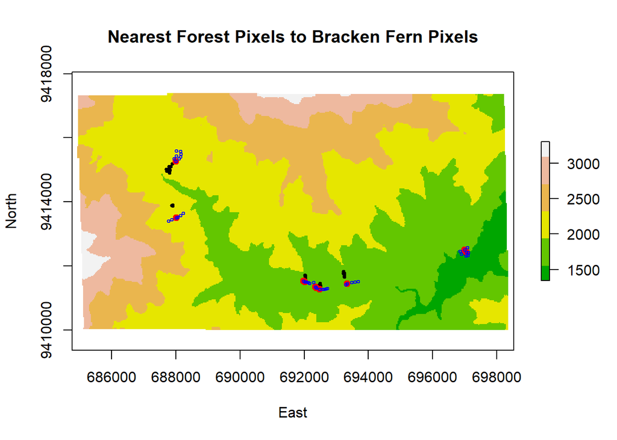

```r
rownames(distmat) <- df_ID_pixels[1:56]
colnames(distmat) <- df_ID_pixels[57:96]
## Rename column names of distmat matrix
distmat_id <- melt(as.matrix(distmat), varnames = c("fern", "forest"))
## Convert nearest_forest_dist into dataframe
nearfdist <-data.frame(nearest_forest_dist)
## Change column name of the nearfdist dataframe
nearfernid<- nearfdist %>% rename(value = nearest_forest_dist)
## Matching using ID_pixel
neardistmat <- right_join(distmat_id,nearfernid, by=c("value"))
view(neardistmat)

######## Step3: Plot nearest bracken fern pixels and forest pixels

## Plot nearest bracken fern and forest pixels
plot(elev_utm, main= "Nearest Forest Pixels to Bracken Fern Pixels", xlab="East", ylab="North", col=myCol,cex=.5)
points(df_fern$x,df_fern$y,col="black",pch=19,cex=.5)
points(df_forest$x[df_fern$nearForestID],
       df_forest$y[df_fern$nearForestID],col="red",pch=19,cex=1)
points(df_forest$x,df_forest$y,col="blue",cex=.5)
```

```r
# Benchmarking for gdistance package:

st1<-system.time(costDistance(conductance,
                      fromCoords = as(as_Spatial(coordnt[1:56,]), "SpatialPoints"),
                      toCoords = as(as_Spatial(coordnt[-(1:56),]), "SpatialPoints")))

#  user  system  elapsed
#  2.42    0.03    2.44

# Benchmarking for igraph package:

st2<-system.time(distances(gr, hex_pixels[(1:56)], hex_pixels[-(1:56)]))

#   user   system  elapsed
#   78.92    0.06   79.56
```

## Packages

For the purpose of calculating the topographic distances, I used gdistance and igraph packages, and the Euclidean function.

The gdistance package was designed to measure distance considering the topographic heterogeneity of any region represented as grids. One requirement of the package is the use of raster files because of their arrangement (rows and columns) and spatial metadata they have, which include information about the extent, dimensions. The gdistance relies on the igraph package because the conversion of the raster into graphs is necessary to generate the distance matrix. An important step of the use of gdistance package is the geocorrection of surface distortion in the transition matrix. In a similar way, the igraph package can be used to measure distance. However, the main difference with the gdistance package is the creation of a hexagonal matrix to generate a graph network. Also, the distance calculation is based on the pairwise shortest path between the set of vertices. While the graphs generate with gdistance connects cell centres to each other. Finally, the igraph does not include a geocorrection function for calculating distance.

The Euclidean function was used to calculate the distance considering the elevation. However, compares to the previous packages, this function does not take into account the geographic features of the surface.

## Final product

Both packages and the Euclidean function gave information about topographic distance. However, the gdistance package provided a better accuracy to calculate the topographic distance. I created a plot to show the nearest pairwise of forest pixels and bracken fern pixels for every package and the Eucliden function.

One concern about the use of gdistance is related to the raster reprojection. To make a comparison about computing distance throw the application of gdistance, igraph, and the Euclidean function, it was necessary to transform the Lat/Long projection of the raster file into the UTM projection. Thus, this reprojection could affect the shape of cells in the raster file, which could have a direct effect on the topographic distance. My next step will be computing the distance using the raster file without reprojected it.

## Reflection

This exercise helped me to explore different ways of computing topographic distances, but also to acquire and improve my skills in spatial analysis. When I started to work in this exercise some weeks ago, my knowledge and skills about the use of the spatial analysis were too limited. However, the trial and error process of running codes and looking for information to fix issues has improved my skills in spatial analysis. Particularly, in the advantages and disadvantages of applying different packages (e.g., sp, sf, rgdal, raster) related to the analysis of geographic features and others related to the organization of my dataset (e.g., dplyr, tibble).

My next step will be learning the process to integrate the Google Earth Engine Platform with R, to download and process satellite images of Sentinel and Landsat sensors.

## Resources

- gdistance: https://mran.microsoft.com/snapshot/2016-08-05/web/packages/gdistance/vignettes/gdistance1.pdf
- igraph: https://igraph.org/r/
- Comparison between Euclidean function, gdistance, iggraph: https://insileco.github.io/2019/04/08/r-as-a-ruler-how-to-calculate-distances-between-geographical-objects/#LeastCostDistanceswithgdistance
- tibble: https://tibble.tidyverse.org/
- reshape2: https://cran.r-project.org/web/packages/reshape2/reshape2.pdf
- dplyr: https://dplyr.tidyverse.org/reference/arrange.html#locales